# Multiplier-Resampling Coverage Sweep

- Show All Code
- Hide All Code
- View Source

95% coverage of the marginal subgroup hazard ratio (C†) vs sample size, for the consistency (FS) detector — León (2024) M1 design

Author

Larry León

Published

August 19, 2026

> **One document, one sweep.** This renders the entire `subgroup_method × n_sample` grid (3 methods × 7 sizes = 21 cells), writes one small results bundle per cell to `results_dir/`, accumulates them into a single coverage grid (`mr_coverage_grid.rds`), and plots C† coverage vs *n*. It is **resumable**: each cell is skipped if its bundle already exists, so you can run a subset today and the rest later and the grid fills in. Set `nb_boots <- NULL` (the default) for the MR-only run; the full-bootstrap (FB) path stays wired but dormant.

> **How to drive it.** 1. *Preliminary:* keep `n_sims` small and subset the sweep (`methods_run`, `n_grid_run`) to a cell or two; render; eyeball. 2. *Production:* bump `n_sims`, restore the full `methods_run` / `n_grid_run`, render. Finished cells are skipped; only new ones compute. 3. *Re-plot only:* set `run_sweep <- FALSE` to rebuild the grid and figures from existing bundles without running anything.

> To force a cell to recompute (e.g. after raising `n_sims`), delete its `*_res.rds` in `results_dir/`.

# 1 What this evaluates

For each cell — one `(subgroup_method, n_sample)` pair — the document runs `n_sims` simulated trials on the León (2024) GBSG-AFT M1 super-population, and on each detected replicate records the **MR** de-biased estimate and interval (`forestsearch(mr_inference = TRUE)`, infinitesimal-jackknife interval) together with the oracle and naive estimators. Coverage is the proportion of detected replicates whose 95% CI contains the target, computed against the **marginal subgroup hazard ratio** θ† (population, *n*-invariant). Because θ† and the other truth targets are properties of the fixed DGM, the DGM is built **once** and reused across every cell, so the coverage-vs-*n* curve compares like with like.

All coverage rates here are **conditional on detecting a subgroup**; the companion detection-rate panel is reported alongside so the curve is read in that light.

# 2 Setup — all knobs

```r
.t0_doc <- Sys.time()

# forestsearch must be INSTALLED (devtools::install()), not load_all(): the
# doFuture multisession workers spawn separate R processes that only see the
# installed package.
library(forestsearch)
library(survival)
library(data.table)
library(ggplot2)
library(foreach)
library(doFuture)
library(future)

# Super-population conditional beta(Hhat)-HR targets (the Theorem-2 estimand).
# API ALIGNMENT (matches the or075 sweep and the m1/h10 batch harness): the
# eval-frame / theta-dagger helpers live in the PACKAGE betaHhat truth layer
# (R/betaHhat_truth.R) and dispatch on outcome_type — build_eval_frame() ->
# fs_build_eval_frame(), betaHhat_theta_dagger_check() ->
# fs_betaHhat_theta_dagger_check().  The working-directory source() copy is
# retired; same construction, same numbers.

# ── The sweep ────────────────────────────────────────────────────────────────
methods  <- c("consistency", "dina", "grf")     # detector axis
n_grid   <- seq(500L, 2000L, by = 250L)         # sample-size axis: 500..2000 by 250 (7)

# Subset these for a preliminary pass; restore to `methods` / `n_grid` for the
# full grid.  (Resumable either way — see the run-sweep chunk.)
methods_run <- "consistency"                     # FS-only: consuming fragments read only FS rows/cells
n_grid_run  <- c(500L, 1000L)                    # exactly the cells the consuming fragments read

# ── Counts (the main knobs for smoke → production) ───────────────────────────
n_sims    <- 500L        # simulated trials per cell        (prod: 1000 → 20000)
nb_boots  <- NULL       # FB nonparametric bootstraps; NULL/0 ⇒ MR-only (FB dormant)
mr_draws <- 5000L     # MR multiplier draws              (keep ~2000–5000)
diag_mode <- FALSE      # TRUE caps each cell to 5 reps.  (Errors no longer need
                        # this to become visible: every replicate failure is
                        # captured in status/err_msg — see the recorder.)

# ── The identifier: focus ────────────────────────────────────────────────────
# Defined HERE, ahead of the run identity it feeds (the engine axis is the
# sweep's methods vector, so focus is the identifier's only free knob).  Under
# "maxeffCons" the consistency arm runs the effect argmax with the consistency
# floor — the one focus where early stopping is sound — while the dina/grf arms
# rank as the plain effect argmax (they compute no Pcons).
sg_focus <- "maxeffCons"

# ── DGM scenario (feeds the run identity) ────────────────────────────────────
dgm_model      <- "alt"
analysis_time  <- 84            # administrative censoring (months)
cens_adjust    <- log(1.5)
n_super        <- 100000L
target_hr_harm <- 1.0           # calibrate k_inter to this Cox HR in the harm subgroup
k_random_noise <- 3             # add k_random_noise standard-normal noise confounders

# ── Run identity (DERIVED — do not hand-edit) ────────────────────────────────
# run_tag identifies THIS run.  results_dir AND the grid filename both derive
# from it, so a change writes to a new folder and a new grid with NO pooling of
# prior runs.  EVERY token is derived from knobs above — nothing hand-typed:
#   scenario  m1_h<10*target_hr_harm>_knoise<k_random_noise>  (one decimal of HR
#             resolution, matching the batch drivers' round(10*x) convention.
#             Previously hard-coded: an h15 clone kept "h10" in its tag, filing
#             a target_hr_harm = 1.5 run under an h10 directory.  Derivation
#             removes that failure mode.)
#   focus     via .FOCUS_TAGS below          engine  "fbmr"/"mr" from nb_boots
#   seedtab   the pre-generated seed-table scheme — never poolable with
#             seed_base + sim_id era bundles; the run-sweep loop additionally
#             guards on meta$seed_scheme when skipping existing cells.
# Convention: <scenario>_<focus_tag>_<engine_tag>_seedtab_s<n_sims>.
# (No fragment reads this document's grid; the _sim_mr_coverage_* fragments
#  hold their own run_tags and payload_dir.  Verified 2026-08-01.)

# Focus token.  Emits a USER-FACING label: the internal "hr*" spelling never
# reaches a filename, and synonyms collapse to ONE token so a single
# configuration cannot produce two directories.
.FOCUS_TAGS <- c(eff = "maxcons", maxcons = "maxcons", hr = "maxcons",
                 effMaxSG = "effMaxSG", hrMaxSG = "effMaxSG",
                 effMinSG = "effMinSG", hrMinSG = "effMinSG",
                 maxeff   = "maxeff",
                 # Distinct rule on the consistency engine; effect argmax on
                 # dina/grf — same convention as the or075 binary sweep.
                 maxeffCons = "maxeffCons")
# Self-explaining fail-loud: a bare [[ dies with "subscript out of bounds",
# which cannot distinguish a typo ("effmaxCons") from a valid focus missing
# from this table, and names neither the value nor the alternatives.
if (!sg_focus %in% names(.FOCUS_TAGS))
  stop("Unrecognised sg_focus '", sg_focus, "' for the run-tag table. Known: ",
       paste(sort(unique(names(.FOCUS_TAGS))), collapse = ", "), call. = FALSE)
focus_tag <- .FOCUS_TAGS[[sg_focus]]

# FB dormancy is the single source of truth for the engine token.  It names the
# bundle files AND the build-grid glob (both via rds_tag), so the two cannot
# fall out of sync; MR-only and FB+MR runs land in separate run_tag directories.
fb_active    <- is.numeric(nb_boots) && length(nb_boots) == 1L && nb_boots >= 1L
engine_tag   <- if (fb_active) "fbmr" else "mr"
scenario_tag <- sprintf("m1_h%02d_knoise%d", round(10 * target_hr_harm), k_random_noise)
campaign_tag <- "standalone1"  # NEW knob: namespaces this fresh standalone campaign into its own
                               # run_tag/dir family; "" reproduces the legacy (pre-campaign) tag.
run_tag      <- sprintf("%s_%s_%s_seedtab_s%d%s", scenario_tag, focus_tag, engine_tag, n_sims,
                        if (nzchar(campaign_tag)) paste0("_", campaign_tag) else "")
results_dir  <- file.path("mr_sweep", run_tag)  # per-run folder: bundles + grid live here
rds_tag      <- engine_tag                 # per-cell engine token; the method tag (fs/dina/grf) LEADS the filename
grid_path    <- file.path(results_dir, sprintf("mr_coverage_grid_%s.rds", run_tag))
cat(sprintf("run_tag: %s\n", run_tag))
```

```
run_tag: m1_h10_knoise3_maxeffCons_mr_seedtab_s500_standalone1
```

```r
# ── Run controls ─────────────────────────────────────────────────────────────
run_sweep   <- TRUE                       # FALSE ⇒ skip computation, just (re)build grid + plots

# ── Parallelization ──────────────────────────────────────────────────────────
# "sims"  -> replicates fan out across workers (each rep's search runs sequentially).
#            BEST for this MR-only sweep: no inner bootstrap, so filling cores with
#            replicates is the throughput win.
# "boots" -> replicates sequential; the search (and, if nb_boots>0, the bootstrap)
#            parallelize WITHIN each replicate.  Prefer only if a cell sets nb_boots>0
#            with small n_sims.
# All draws are explicitly seeded via the pre-generated seed table (seed_for(),
# below) AND the recorder pins RNGkind, so results are plan-invariant: the modes
# differ in wall-clock only.  (Without the RNGkind pin that claim was FALSE —
# simulate_from_dgm() keeps the ambient RNG kind, Mersenne-Twister sequentially
# vs L'Ecuyer-CMRG under %dofuture%, so "sims" and "boots" drew DIFFERENT data
# from the same seed.  Demonstrated 2026-08-18: the boots-mode fb_mr_1_100
# bundle disagrees with sims-mode runs on n_true for 95/100 sims.)
parallel_mode <- "sims"

# ── Seeds: PRE-GENERATED, indexed by GLOBAL replicate id ─────────────────────
# ADOPTED FROM THE OR075 SWEEP / MD-HARM HARNESS.  Results must be invariant to
# worker count and to batch position, so the seed for replicate i is looked up,
# never derived from loop position (and no longer derived arithmetically from
# sim_id).  NOT back-compatible with seed_base + sim_id bundles — the run_tag
# carries a "seedtab" token and the run-sweep loop refuses to mix schemes.
seed_base  <- 8316951L
MAX_SIMS   <- 5000L
set.seed(seed_base)
SEED_TABLE <- sample.int(.Machine$integer.max - 1L, MAX_SIMS)
seed_for <- function(sim_id) {
  if (sim_id < 1L || sim_id > MAX_SIMS)
    stop("sim_id ", sim_id, " outside the pre-generated seed table.")
  SEED_TABLE[sim_id]
}
seed_scheme <- "pre-generated table indexed by global sim_id"

# ── Noise covariates live in the SUPER-POPULATION ────────────────────────────
# Noise is a fixed subject characteristic of the universe, drawn ONCE at DGM
# construction by setup_gbsg_dgm(k_random_noise, noise_seed) itself
# (forestsearch >= 0.2.2; scheme of 2a4787bc) — NOT per trial and NOT by this
# driver.  Trials sample
# rows of df_super, so they inherit the same noise values automatically, and
# fs_build_eval_frame() evaluates df_super itself, so a selected rule that
# includes a noise variable RESOLVES on the evaluation frame and beta(Hhat) is
# computable.  Under the old per-trial draw, such rules were "unresolved"
# (.fs_resolve_membership: a rule the frame cannot express has no membership),
# silently shrinking every C_betaHhat denominator and tripping
# fs_betaHhat_neff_parity() at grid build.
noise_seed <- 20260807L              # passed to the builder; matches the
                                     # committed population-noise scheme
                                     # (2a4787bc, gbsg_redux knoise sweeps) and
                                     # is disjoint from SEED_TABLE / eval_seed
confounders_base_plus <- character(0)  # finalized in build-dgm from dgm$noise_names

n_workers <- max(1L, ceiling(0.90 * (parallel::detectCores(logical = FALSE) - 1L)))
# n_workers <- 40L   # OPTIONAL core-share: uncomment while another sweep is live in RStudio
inner_parallel <- if (identical(parallel_mode, "boots"))
  list(plan = "multisession", workers = n_workers) else list(plan = "sequential")
z975 <- qnorm(0.975)

# ── Search configuration (León tuning; resample identification) ──────────────
# (sg_focus and the DGM scenario live in the identifier / run-identity blocks
#  above, which derive the run_tag from them.)
consistency_method <- "resample"
selection_rule     <- "neighborhood"
effect_neighborhood <- 0.10  # package default; band half-width for the eff*SG
                             # foci.  Pinned for visibility; inert under
                             # sg_focus = "maxcons" (canonical "hr").
stop_threshold     <- NULL   # EARLY STOPPING — pinned for visibility.  Under
# "maxcons" (canonical "hr") forestsearch() resets the coupled default to NULL
# silently, so this changes nothing here; it exists so the configuration states
# what runs, and so a future switch to "maxeffCons" (where the default WOULD be
# live at 0.90) cannot inherit early stopping unseen.
hr_threshold   <- 0.90
hr_consistency <- 0.80
pconsistency   <- 0.90
fs_splits <- 400L; maxk <- 2L; n_min <- NULL; d0_min <- 10L; d1_min <- 0L
use_lasso <- FALSE; use_dina <- FALSE; use_grf <- FALSE; use_twostage <- TRUE
fs_conf_force      <- c("meno == 0", "er <= 0", "pgr <= 0")   # premenopausal (raw analog of z3 == 1)
fs_conf.cont_jcuts <- list(er = 10)                          # J-quantile grid on raw ER

# Method-specific selectors (only the matching block is used per cell).
grf_selection <- "frontier"; grf_select_statistic <- "effect"
grf_depth <- 2L; dmin.grf <- 0.0
dina_args <- list(); dina_select_statistic <- "effect"


# ── Column names emitted by simulate_from_dgm() ──────────────────────────────
outcome_name <- "y_sim"; event_name <- "event_sim"; treat_name <- "treat_sim"
id_name <- "id"; harm_col <- "flag_harm"
confounders_base <- c("er", "age", "meno", "pgr", "nodes", "size", "grade")

`%||%` <- function(a, b) if (is.null(a) || length(a) == 0 || all(is.na(a))) b else a

cat(sprintf("Sweep: %d method(s) × %d size(s) = %d cell(s) to consider.\n",
            length(methods_run), length(n_grid_run),
            length(methods_run) * length(n_grid_run)))
```

```
Sweep: 1 method(s) × 2 size(s) = 2 cell(s) to consider.
```

```r
cat(sprintf("Counts: n_sims=%d, nb_boots=%s (MR-only=%s), mr_draws=%d.\n",
            n_sims, if (is.null(nb_boots)) "NULL" else as.character(nb_boots),
            if (is.null(nb_boots) || identical(nb_boots, 0L)) "yes" else "no", mr_draws))
```

```
Counts: n_sims=500, nb_boots=NULL (MR-only=yes), mr_draws=5000.
```

```r
cat(sprintf("Parallel: %s · %d workers · seed_base=%d.\n",
            parallel_mode, n_workers, seed_base))
```

```
Parallel: sims · 115 workers · seed_base=8316951.
```

# 3 Build the DGM once (n-invariant truth)

```r
dgm <- NULL; truth <- NULL; eval_df <- NULL
if (run_sweep) {
  k_inter <- calibrate_k_inter(target_hr_harm = target_hr_harm,
                               model = dgm_model, use_ahr = FALSE)
  dgm <- setup_gbsg_dgm(model = dgm_model, k_inter = k_inter,
                        n_super = n_super, seed = seed_base,
                        k_random_noise = k_random_noise,
                        noise_seed = noise_seed)
  dgm <- compute_dgm_cde(dgm)   # attaches CDE (θ‡) targets

  # ---- Noise covariates: drawn by the BUILDER (forestsearch >= 0.2.2) -------
  # setup_gbsg_dgm() draws them once onto the super-population at construction
  # (scheme of 2a4787bc) and records noise_names / noise_scheme / noise_seed on
  # the returned object; compute_dgm_cde() and fs_build_eval_frame() carry the
  # columns through (package test test-knoise-population.R, assertion 5).  The
  # driver only ASSERTS — no draw remains here, so builder + driver double
  # application is structurally impossible.
  stopifnot(
    identical(dgm$noise_scheme, if (k_random_noise > 0) "population" else "none"),
    identical(length(dgm$noise_names), as.integer(k_random_noise)),
    all(dgm$noise_names %in% names(dgm$df_super))
  )
  if (k_random_noise > 0)
    cat(sprintf("Noise covariates in df_super (builder draw): %s (seed %d)\n",
                paste(dgm$noise_names, collapse = ", "), dgm$noise_seed))
  confounders_base_plus <- c(confounders_base, dgm$noise_names)

  truth <- list(
    hr_causal = dgm$hr_causal  %||% NA_real_,                 # overall causal HR
    marg_H    = dgm$hr_H_true  %||% NA_real_,                 # θ†  (H)
    marg_Hc   = dgm$hr_Hc_true %||% NA_real_,                 # θ†  (Hc)
    cde_H     = dgm$cde_H  %||% (dgm$hazard_ratios$CDE_harm    %||% NA_real_),  # θ‡ (H)
    cde_Hc    = dgm$cde_Hc %||% (dgm$hazard_ratios$CDE_no_harm %||% NA_real_)   # θ‡ (Hc)
  )
  cat("DGM truth targets (population, shared by every cell):\n")
  cat(sprintf("  overall causal HR    : %.3f\n", truth$hr_causal))
  cat(sprintf("  θ†  (marginal)  H/Hc : %.3f / %.3f\n", truth$marg_H, truth$marg_Hc))
  cat(sprintf("  θ‡  (CDE)       H/Hc : %.3f / %.3f\n", truth$cde_H,  truth$cde_Hc))

  # beta(Hhat)-HR evaluation frame: the ENTIRE super-population, each subject once
  # (replace = FALSE), under the SAME randomized/censored analysis (analysis_time,
  # cens_adjust) -- the Theorem-2 conditional target's evaluation population.
  eval_df <- fs_build_eval_frame(dgm, outcome_type = "survival",
                                 eval_seed = 20260628L,
                                 analysis_time = analysis_time,
                                 cens_adjust = cens_adjust)
  .td_chk <- fs_betaHhat_theta_dagger_check(eval_df, outcome_type = "survival",
                                            harm.name = harm_col,
                                            outcome.name = outcome_name,
                                            event.name = event_name,
                                            treat.name = treat_name)
  cat(sprintf("  beta(Hhat) eval frame: n=%d (FULL super-population, each subject once; eval_seed = 20260628)\n", nrow(eval_df)))
  cat(sprintf("  theta-dagger check   : %.3f / %.3f  (eval frame at true H/Hc; matches marginal HR above)\n", .td_chk["thetaDagger_H"], .td_chk["thetaDagger_Hc"]))
} else {
  cat("run_sweep = FALSE: DGM build skipped (grid rebuilt from existing bundles).\n")
}
```

```
Noise covariates in df_super (builder draw): noise1, noise2, noise3 (seed 20260807)
DGM truth targets (population, shared by every cell):
  overall causal HR    : 0.685
  θ†  (marginal)  H/Hc : 1.000 / 0.657
  θ‡  (CDE)       H/Hc : 1.000 / 0.585
  beta(Hhat) eval frame: n=100000 (FULL super-population, each subject once; eval_seed = 20260628)
  theta-dagger check   : 1.003 / 0.628  (eval frame at true H/Hc; matches marginal HR above)
```

# 4 Per-replicate recorder

`record_replicate()` takes the cell axes (`method`, `n_sample`) explicitly and reads the fixed configuration from the setup chunk. Everything else mirrors the single-cell recorder: identify Ĥ + naive + MR correction in one `forestsearch()` call, optionally run the FB bootstrap (skipped when `nb_boots` is NULL/0), and refit the oracle on the true harm subgroup. A failure returns an all-NA record so the loop never aborts a cell.

```r
# Cox HR + delta-method 95% CI on a subset (the per-replicate oracle target).
# Guards separation: non-finite coef/SE returns a clean NA triple, not Inf bounds.
.cox_hr_ci <- function(df) {
  if (sum(df[[event_name]]) < 5L || length(unique(df[[treat_name]])) < 2L)
    return(c(est = NA_real_, lo = NA_real_, hi = NA_real_, se = NA_real_))
  fml <- stats::as.formula(sprintf("survival::Surv(%s, %s) ~ %s",
                                   outcome_name, event_name, treat_name))
  fit <- tryCatch(survival::coxph(fml, data = df), error = function(e) NULL)
  if (is.null(fit)) return(c(est = NA_real_, lo = NA_real_, hi = NA_real_, se = NA_real_))
  b <- unname(stats::coef(fit)[1])
  v <- unname(suppressWarnings(diag(stats::vcov(fit))[1]))
  se <- if (is.finite(v) && v > 0) sqrt(v) else NA_real_
  if (!is.finite(b) || !is.finite(se))
    return(c(est = NA_real_, lo = NA_real_, hi = NA_real_, se = NA_real_))
  c(est = exp(b), lo = exp(b - z975 * se), hi = exp(b + z975 * se), se = se)
}

# Classification of Ĥ vs the true harm flag.
# Recover the log-HR (beta) SE from an HR-scale SD (sdH2): se_beta = sdH2 / HR.
# Used for the FB row when the bootstrap is enabled; NA on a non-finite/<=0 HR.
.se_beta_hr <- function(sd_hr, hr) {
  if (is.finite(sd_hr) && is.finite(hr) && hr > 0) sd_hr / hr else NA_real_
}

.classify <- function(sg_hat, truth_flag) {
  out <- c(sens = NA_real_, spec = NA_real_, ppv = NA_real_, npv = NA_real_)
  if (is.null(sg_hat) || length(sg_hat) != length(truth_flag)) return(out)
  sg_hat <- as.integer(sg_hat); truth_flag <- as.integer(truth_flag)
  tp <- sum(sg_hat == 1 & truth_flag == 1); fp <- sum(sg_hat == 1 & truth_flag == 0)
  fn <- sum(sg_hat == 0 & truth_flag == 1); tn <- sum(sg_hat == 0 & truth_flag == 0)
  out["sens"] <- if (tp + fn > 0) tp / (tp + fn) else NA_real_
  out["spec"] <- if (tn + fp > 0) tn / (tn + fp) else NA_real_
  out["ppv"]  <- if (tp + fp > 0) tp / (tp + fp) else NA_real_
  out["npv"]  <- if (tn + fn > 0) tn / (tn + fn) else NA_real_
  out
}

# One all-NA record (returned on failure so the loop never aborts a cell).
.na_record <- function(sim_id) data.frame(
  sim_id = sim_id, seed = NA_integer_, detected = 0L, mr_ok = 0L,
  n_sel = NA_integer_,
  # ADOPTED FROM THE OR075 SWEEP: the CONFIG-ERROR / NO-DETECTION / DETECTED
  # trichotomy.  `detected` alone cannot distinguish "the search ran and found
  # nothing" from "the replicate never got that far", so a broken configuration
  # reads as a scientific null in every downstream rate.  On CONFIG-ERROR,
  # detected and mr_ok are NA (not 0): nothing was searched.  err_msg carries
  # the error; mr_msg the captured MR announcements.
  status = NA_character_, err_msg = NA_character_, mr_msg = NA_character_,
  n_harm = NA_integer_, n_true = NA_integer_,
  label = NA_character_, sg_def = NA_character_, covs = NA_character_,
  betaHhat_H = NA_real_, betaHhat_Hc = NA_real_,
  fb_secs = NA_real_, fit_mr_secs = NA_real_, fb_err = NA_character_,
  or_H_est = NA, or_H_lo = NA, or_H_hi = NA, or_H_se = NA,
  or_Hc_est = NA, or_Hc_lo = NA, or_Hc_hi = NA, or_Hc_se = NA,
  nv_H_est = NA, nv_H_lo = NA, nv_H_hi = NA, nv_H_se = NA,
  nv_Hc_est = NA, nv_Hc_lo = NA, nv_Hc_hi = NA, nv_Hc_se = NA,
  fb_H_est = NA, fb_H_lo = NA, fb_H_hi = NA, fb_H_se = NA,
  fb_Hc_est = NA, fb_Hc_lo = NA, fb_Hc_hi = NA, fb_Hc_se = NA,
  mr_H_est = NA, mr_H_lo = NA, mr_H_hi = NA, mr_H_se_ij = NA,
  mr_Hc_est = NA, mr_Hc_lo = NA, mr_Hc_hi = NA, mr_Hc_se_ij = NA,
  mr_harm_flag = NA_integer_, ij_source = NA_character_,
  sens = NA_real_, spec = NA_real_, ppv = NA_real_, npv = NA_real_,
  stringsAsFactors = FALSE)

# rule_covs(): variable names appearing in a realized rule (for the
# identification figures) — same inline wrapper as the batch harnesses.
rule_covs <- function(rule) forestsearch:::.fs_rule_columns(rule)

record_replicate <- function(sim_id, method, n_sample, nb_boots) {
  run_fb <- fb_active   # single source of truth, set in setup
  rec <- .na_record(sim_id)
  sd_i <- seed_for(sim_id)                # global-id lookup, not position
  rec$seed <- sd_i

  # Pin the RNG kind.  simulate_from_dgm() calls set.seed(seed) with
  # kind = NULL, which KEEPS the ambient kind, so the realized draw depends on
  # whichever kind the backend installed — Mersenne-Twister sequentially,
  # L'Ecuyer-CMRG under %dofuture% with seed = TRUE.  Pinning it here makes a
  # replicate the same replicate however it is run (D.2; and see the 2026-08-18
  # fb_mr_1_100 finding in the parallel-mode comment above).
  RNGkind("L'Ecuyer-CMRG")
  set.seed(sd_i)

  df <- tryCatch(
    simulate_from_dgm(dgm, n = n_sample, analysis_time = analysis_time,
                      cens_adjust = cens_adjust, seed = sd_i),
    error = function(e) NULL)
  if (is.null(df)) {
    rec$status <- "CONFIG-ERROR"
    rec$detected <- NA_integer_; rec$mr_ok <- NA_integer_
    return(rec)
  }
  df[[id_name]] <- seq_len(nrow(df))
  # Noise covariates arrive WITH the sampled subjects: they were drawn once
  # into df_super by setup_gbsg_dgm() at DGM construction, so simulate_from_dgm()'s
  # row-resampling carries them here with the same values the evaluation frame
  # holds.  NO per-trial draw — a per-trial rnorm() here would overwrite the
  # inherited columns and detach the trial's noise from the frame's, making
  # noise-containing rules unresolvable for beta(Hhat) again.
  confs <- intersect(confounders_base_plus, names(df))

  rec$n_true <- sum(df[[harm_col]] == 1L, na.rm = TRUE)

  # ---- Identification + naive + MR correction (single forestsearch call) ----
  base_args <- list(
    df.analysis     = df,
    outcome.name    = outcome_name, event.name = event_name,
    treat.name      = treat_name,   id.name    = id_name,
    flag_harm.name  = harm_col,     confounders.name = confs,
    is.RCT          = TRUE,         seedit = sd_i,
    # quiet = FALSE so the .mr_skip announcement is emitted; captured below as
    # messages (mr_msg) rather than printed (or075 sweep, D.1/D.4).
    quiet           = FALSE,
    sg_focus        = sg_focus,
    subgroup_method = method,
    hr.threshold    = hr_threshold, hr.consistency = hr_consistency,
    pconsistency.threshold = pconsistency, n.min = n_min,
    selection_rule  = selection_rule,
    effect_neighborhood = effect_neighborhood,
    stop_threshold  = stop_threshold,   # see @sec-setup: inert under "maxcons", pinned for visibility
    parallel_args   = inner_parallel,
    mr_inference     = TRUE,
    mr_inference_args = list(ci_method = "ij", draws = mr_draws,
                            include_complement = TRUE))
  method_args <- switch(
    method,
    consistency = list(
      consistency_method = consistency_method,
      use_lasso = use_lasso, use_grf = use_grf, use_twostage = use_twostage,
      use_dina = use_dina, conf_force = fs_conf_force,
      conf.cont_jcuts = fs_conf.cont_jcuts,
      fs.splits = fs_splits, maxk = maxk, d0.min = d0_min, d1.min = d1_min),
    dina = list(dina_select_statistic = dina_select_statistic, dina_args = dina_args),
    grf  = list(grf_selection = grf_selection, grf_depth = grf_depth,
                dmin.grf = dmin.grf, grf_select_statistic = grf_select_statistic),
    stop("unknown subgroup_method: ", method))
```

```r
  # Diagnostics are CAPTURED, never swallowed (or075 sweep, D.1/D.4).  BOTH
  # streams: the message stream carries .mr_msg()/.mr_skip(); the stdout stream
  # carries the per-replicate "MR harm confirmation" cat() (package-side fix
  # queued), which future would otherwise relay from every worker into the
  # render.
  mr_t0 <- proc.time()[3]
  fs.est  <- NULL
  outs    <- character(0)
  err_msg <- NA_character_
  msgs <- tryCatch(
    utils::capture.output(
      outs <- utils::capture.output(
        fs.est <- suppressWarnings(do.call(forestsearch, c(base_args, method_args))),
        type = "output"),
      type = "message"),
    error = function(e) { err_msg <<- conditionMessage(e); character(0) })
  rec$fit_mr_secs <- proc.time()[3] - mr_t0

  # Diagnostic MR lines only: the routine announce and the harm-confirmation
  # echo are dropped (harm_flag already lands in mr_harm_flag).
  mr_all <- grep("multiplier resampling|mr_inference|MR harm", c(msgs, outs),
                 value = TRUE)
  mr_keep <- mr_all[!grepl("constructing de-biased estimates|MR harm confirmation",
                           mr_all)]
  if (length(mr_keep)) rec$mr_msg <- paste(mr_keep, collapse = " | ")

  # CONFIG-ERROR: forestsearch() refused the call.  Distinct from NO-DETECTION,
  # and recorded as NA rather than 0 — nothing was ever searched.
  if (!is.na(err_msg) || is.null(fs.est)) {
    rec$status   <- "CONFIG-ERROR"
    rec$err_msg  <- err_msg
    rec$detected <- NA_integer_
    rec$mr_ok    <- NA_integer_
    return(rec)
  }

  g     <- fs.est$mr_inference
  found <- !is.null(fs.est$sg.harm) && length(fs.est$sg.harm) > 0 &&
           !all(is.na(fs.est$sg.harm))
  rec$detected <- as.integer(found)
  if (!found) { rec$status <- "NO-DETECTION"; return(rec) }
  rec$status <- "DETECTED"
  rec$sg_def <- paste(fs.est$sg.harm, collapse = " & ")   # realized rule -> beta(Hhat)
  rec$covs   <- paste(rule_covs(fs.est$sg.harm), collapse = "+")  # variable names -> id figures
  rec$mr_ok <- as.integer(!is.null(g))

  if (!is.null(g)) {
    rec$label <- g$selected_label %||% NA_character_
    rec$n_sel <- g$n_selected      %||% NA_integer_
    rec$mr_harm_flag <- as.integer(isTRUE(g$harm_flag))
    rec$ij_source    <- g$debiased$ij_source %||% NA_character_
    rec$nv_H_est <- g$naive$est;    rec$nv_H_lo <- g$naive$lower;    rec$nv_H_hi <- g$naive$upper;    rec$nv_H_se <- g$debiased$se_wald %||% NA_real_
    rec$mr_H_est <- g$debiased$est; rec$mr_H_lo <- g$debiased$lower; rec$mr_H_hi <- g$debiased$upper
    rec$mr_H_se_ij <- g$debiased$se_ij %||% NA_real_
    if (is.list(g$complement) && !is.null(g$complement$debiased)) {
      rec$nv_Hc_est <- g$complement$naive$est
      rec$nv_Hc_lo  <- g$complement$naive$lower
      rec$nv_Hc_hi  <- g$complement$naive$upper
      rec$nv_Hc_se  <- g$complement$debiased$se_wald %||% NA_real_
      rec$mr_Hc_est <- g$complement$debiased$est
      rec$mr_Hc_lo  <- g$complement$debiased$lower
      rec$mr_Hc_hi  <- g$complement$debiased$upper
      rec$mr_Hc_se_ij <- g$complement$debiased$se_ij %||% NA_real_
    }
  }

  cl <- .classify(fs.est$grp.consistency$sg.harm.id, df[[harm_col]])
  rec$sens <- cl["sens"]; rec$spec <- cl["spec"]; rec$ppv <- cl["ppv"]; rec$npv <- cl["npv"]
  rec$n_harm <- sum(fs.est$grp.consistency$sg.harm.id == 1L, na.rm = TRUE)

  # ---- FB bootstrap (H2 = León Eq.7) — dormant when nb_boots NULL/0 ----------
  if (run_fb && method %in% c("consistency", "dina", "grf")) {
    fb_t0 <- proc.time()[3]; fb_err <- NA_character_
    boot <- tryCatch(
      forestsearch_bootstrap_dofuture(fs.est, nb_boots = nb_boots,
                                      seed = sd_i,   # table seed: one scheme everywhere (DGM, search, FB)
                                      parallel_args = inner_parallel),
      error = function(e) { fb_err <<- conditionMessage(e); NULL })
    rec$fb_secs <- proc.time()[3] - fb_t0
    rec$fb_err  <- fb_err
    if (!is.null(boot) && !is.null(boot$H_estimates)) {
      he <- boot$H_estimates
      rec$fb_H_est <- he$H2 %||% NA_real_
      rec$fb_H_lo  <- he$H2_lower %||% NA_real_
      rec$fb_H_hi  <- he$H2_upper %||% NA_real_
      rec$fb_H_se  <- .se_beta_hr(he$sdH2 %||% NA_real_, he$H2 %||% NA_real_)
    }
    if (!is.null(boot) && !is.null(boot$Hc_estimates)) {
      hce <- boot$Hc_estimates
      rec$fb_Hc_est <- hce$H2 %||% NA_real_
      rec$fb_Hc_lo  <- hce$H2_lower %||% NA_real_
      rec$fb_Hc_hi  <- hce$H2_upper %||% NA_real_
      rec$fb_Hc_se  <- .se_beta_hr(hce$sdH2 %||% NA_real_, hce$H2 %||% NA_real_)
    }
  }

  # ---- Oracle: refit on the TRUE harm subgroup of this trial ----------------
  oH  <- .cox_hr_ci(df[df[[harm_col]] == 1, , drop = FALSE])
  oHc <- .cox_hr_ci(df[df[[harm_col]] == 0, , drop = FALSE])
  rec$or_H_est  <- oH["est"];  rec$or_H_lo  <- oH["lo"];  rec$or_H_hi  <- oH["hi"];  rec$or_H_se  <- oH["se"]
  rec$or_Hc_est <- oHc["est"]; rec$or_Hc_lo <- oHc["lo"]; rec$or_Hc_hi <- oHc["hi"]; rec$or_Hc_se <- oHc["se"]

  rec
}

# Replicate-level error firewall (or075 sweep / m1-h10 batch harness).
# record_replicate() guards the simulate and forestsearch calls internally, but
# everything else in its body — notably the base_args/method_args construction —
# runs unguarded, so a setup mistake escapes as an error from the replicate
# itself.  Both run paths would DISCARD such a replicate silently
# (.errorhandling = "remove"; the outer tryCatch), so an all-replicate config
# failure produced results = NULL and read downstream as "no detections".
# Returning the NA record WITH the message keeps the row — and the reason — in
# the bundle.
.safe_record <- function(s, method, n_sample, nb_boots) {
  tryCatch(record_replicate(s, method, n_sample, nb_boots), error = function(e) {
    rec <- .na_record(s); rec$err_msg <- conditionMessage(e)
    rec$status <- "CONFIG-ERROR"
    rec$detected <- NA_integer_; rec$mr_ok <- NA_integer_
    rec
  })
}
```

# 5 `run_cell()` — one (method, n) → one bundle

```r
# Runs `n_sims` replicates for one cell and returns (and optionally writes) the
# bundle list(results, truth, meta) — exactly the structure the original
# single-cell doc saved, so downstream readers (and the per-cell León-Table view
# in _sim_estimation_fs_*.qmd) consume it unchanged.
run_cell <- function(method, n_sample, nb_boots = NULL, out = NULL,
                     sim_id_start = 1L) {
  sim_ids <- sim_id_start:(sim_id_start + n_sims - 1L)
  if (isTRUE(diag_mode)) sim_ids <- utils::head(sim_ids, 5L)

  t0 <- proc.time()[3]
  if (identical(parallel_mode, "sims")) {
    plan("sequential"); gc(); plan("multisession", workers = n_workers)
    results <- foreach(
      s = sim_ids, .combine = rbind, .errorhandling = "remove",
      .options.future = list(packages = c("forestsearch", "survival", "data.table"),
                             seed = TRUE)
    ) %dofuture% .safe_record(s, method, n_sample, nb_boots)
    plan("sequential"); gc()
  } else {
    plan("sequential"); gc()
    results <- do.call(rbind, lapply(sim_ids, function(s)
      .safe_record(s, method, n_sample, nb_boots)))
    plan("sequential"); gc()
  }
  elapsed <- proc.time()[3] - t0

  # ---- Guards (or075 sweep): fail loudly, name the real reason --------------
  if (!is.data.frame(results) || !nrow(results))
    stop(sprintf("run loop produced no usable records for %s n=%d (sim_id %d-%d).",
                 method, n_sample, min(sim_ids), max(sim_ids)), call. = FALSE)
  .cfg_err <- unique(stats::na.omit(results$err_msg))
  if (length(.cfg_err) && all(!is.na(results$err_msg)))
    stop("CONFIG ERROR — every replicate failed before any search ran.\n",
         "Distinct message(s):\n",
         paste0("  - ", .cfg_err, collapse = "\n"), call. = FALSE)
  if (length(.cfg_err))
    warning(sprintf("[%s n=%d] %d of %d replicate(s) failed: %s", method, n_sample,
                    sum(!is.na(results$err_msg)), nrow(results),
                    paste(.cfg_err, collapse = " | ")), call. = FALSE)

  # Attach the per-replicate beta(Hhat)-HR / beta(Hhat^c)-HR targets (Theorem 2),
  # deduplicated over distinct realized rules, on the full-pool eval frame in THIS
  # (main) process -- not inside the workers.
  # RE-POINTED at the package (migration step 4a).  focus = "harm" is exactly
  # what the shim's hard-coded treat.recommend == 0L convention meant.  The
  # richer columns -- betaHhat_status, nH_eval, nHc_eval -- are KEPT on the
  # bundle: that is D4's visibility finally reaching the results, so a reader
  # can see the resolution status and the partition without re-deriving them.
  results <- forestsearch::fs_attach_betaHhat(
    results, eval_df, focus = "harm", outcome_type = "survival",
    outcome.name = outcome_name, event.name = event_name,
    treat.name = treat_name)

  bundle <- list(
    results = results, truth = truth,
    meta = list(n_sample = n_sample, n_sims = n_sims,
                nb_boots = if (is.null(nb_boots)) NA_integer_ else nb_boots,
                mr_draws = mr_draws, subgroup_method = method,
                sim_id_start = sim_id_start, sim_id_end = max(sim_ids),
                seed_base = seed_base, parallel_mode = parallel_mode,
                elapsed_sec = elapsed,
                # --- provenance, RECORD ONLY ------------------------------
                # Never added to the agreement check in accumulate_coverage():
                # that compares truth and seed_base only.  A missing field would
                # resolve to NA there and NA counts as a distinct value, so every
                # bundle written before this change would stop() the pool.  These
                # exist so a bundle can be identified after the fact -- which DGM
                # cell, which config, which build -- never as an agreement key.
                run_tag             = run_tag,
                dgm_model           = dgm_model,
                target_hr_harm      = target_hr_harm,
                k_random_noise      = k_random_noise,
                # Read from the dgm object (builder-recorded, forestsearch >=
                # 0.2.2): meta reports what the builder DID, not what the driver
                # intended.  "population" matches the committed scheme's spelling
                # (2a4787bc) so gbsg_redux and gbsg_020 bundles filter/pool
                # identically; legacy per-replicate bundles carry no noise_scheme.
                noise_scheme        = dgm$noise_scheme,
                noise_seed          = dgm$noise_seed,
                noise_names         = dgm$noise_names,
                analysis_time       = analysis_time,
                cens_adjust         = cens_adjust,
                sg_focus            = sg_focus,
                focus_tag           = focus_tag,
                engine_tag          = engine_tag,
                consistency_method  = consistency_method,
                selection_rule      = selection_rule,
                effect_neighborhood = effect_neighborhood,
                stop_threshold      = paste(deparse(stop_threshold), collapse = " "),
                eval_seed           = 20260628L,
                seed_scheme         = seed_scheme,
                pkg_commit          = tryCatch(
                  system("git rev-parse --short HEAD", intern = TRUE)[1],
                  error = function(e) NA_character_),
                forestsearch_version =
                  as.character(utils::packageVersion("forestsearch")),
                n_workers           = n_workers,
                r_version           = as.character(getRversion()),
                hostname            = unname(Sys.info()[["nodename"]]),
                built_at            = Sys.time()))
  if (!is.null(out)) saveRDS(bundle, out)
  bundle
}
```

# 6 Coverage post-processing helpers (inlined)

```r
.EST_KEYS   <- c(oracle = "or", naive = "nv", FB = "fb", MR = "mr")
.TARGET_COL <- c(oracle = "C_oracle", cde = "C_ddagger", marg = "C_dagger", betaHhat = "C_betaHhat")

# Coverage + uncertainty for one (target, lo, hi) triple.  The finite-only mask
# reproduces the original .cover() exactly; n_eff / mc_se / Wilson are additions.
.coverage_meta <- function(target, lo, hi, conf = 0.95) {
  n <- length(lo); target <- rep_len(target, n)
  ok <- is.finite(target) & is.finite(lo) & is.finite(hi)
  n_eff <- sum(ok)
  if (n_eff == 0L)
    return(data.frame(coverage = NA_real_, n_eff = 0L, n_cov = NA_integer_,
                      mc_se = NA_real_, wilson_lo = NA_real_, wilson_hi = NA_real_))
  hit <- target[ok] >= lo[ok] & target[ok] <= hi[ok]
  k <- sum(hit); p <- k / n_eff
  mc_se <- sqrt(p * (1 - p) / n_eff)
  z <- stats::qnorm(1 - (1 - conf) / 2)
  den <- 1 + z^2 / n_eff
  ctr <- (p + z^2 / (2 * n_eff)) / den
  hw  <- (z / den) * sqrt(p * (1 - p) / n_eff + z^2 / (4 * n_eff^2))
  data.frame(coverage = p, n_eff = n_eff, n_cov = k, mc_se = mc_se,
             wilson_lo = max(0, ctr - hw), wilson_hi = min(1, ctr + hw))
}

# CI length (HR scale, hi - lo) for one (estimator, block); target-independent, so
# summarised once per (method, n, block, estimator) rather than per coverage target.
# Median is the headline (robust to the occasional IJ blow-up); IQR carries spread.
.length_meta <- function(lo, hi) {
  len <- hi - lo; len <- len[is.finite(len)]
  if (!length(len))
    return(data.frame(len_med = NA_real_, len_mean = NA_real_,
                      len_q25 = NA_real_, len_q75 = NA_real_, n_len = 0L))
  q <- stats::quantile(len, c(0.25, 0.75), names = FALSE, type = 7)
  data.frame(len_med = stats::median(len), len_mean = mean(len),
             len_q25 = q[1], len_q75 = q[2], n_len = length(len))
}

# One bundle (path or list) → tidy one-row-per (method, n, block, estimator, target).
coverage_from_bundle <- function(bundle,
                                 estimators = c("oracle", "naive", "MR"),
                                 blocks = c("H", "Hc"),
                                 targets = c("marg", "cde", "betaHhat"),
                                 drop_all_na = TRUE, src = NULL) {
  if (is.character(bundle)) {
    stopifnot(file.exists(bundle)); if (is.null(src)) src <- basename(bundle)
    bundle <- readRDS(bundle)
  }
  if (is.null(src)) src <- NA_character_
  res <- bundle$results; tr <- bundle$truth; meta <- bundle$meta
  if ("FB" %in% estimators &&
      is.na(bundle$meta$nb_boots %||% NA_integer_))
    stop("FB requested but this bundle was written with nb_boots dormant ",
         "(MR-only): the fb_* columns are all NA by construction.",
         call. = FALSE)
  stopifnot(is.data.frame(res), is.list(tr), is.list(meta))
  rH <- res[res$detected %in% 1L, , drop = FALSE]   # %in%: NA-safe (CONFIG-ERROR rows carry detected = NA)

  rows <- list()
  for (blk in blocks) {
    tgt_val <- list(oracle   = rH[[paste0("or_", blk, "_est")]],
                    cde      = tr[[paste0("cde_",  blk)]],
                    marg     = tr[[paste0("marg_", blk)]],
                    betaHhat = if (!is.null(rH[[paste0("betaHhat_", blk)]]))
                                 rH[[paste0("betaHhat_", blk)]] else rep(NA_real_, nrow(rH)))
    for (est in estimators) {
      k  <- .EST_KEYS[[est]]
      lo <- rH[[paste0(k, "_", blk, "_lo")]]; hi <- rH[[paste0(k, "_", blk, "_hi")]]
      for (tg in targets) {
        cm <- .coverage_meta(tgt_val[[tg]], lo, hi)
        rows[[length(rows) + 1L]] <- cbind(
          data.frame(subgroup_method = meta$subgroup_method %||% NA_character_,
                     n_sample = meta$n_sample %||% NA_integer_,
                     block = blk, estimator = est,
                     target = unname(.TARGET_COL[[tg]]), stringsAsFactors = FALSE),
          cm,
          data.frame(n_sims = meta$n_sims %||% NA_integer_, n_detected = nrow(rH),
                     det_rate = if (nrow(res)) mean(res$detected, na.rm = TRUE) else NA_real_,
                     mr_draws = meta$mr_draws %||% NA_integer_,
                     nb_boots = meta$nb_boots %||% NA_integer_,
                     seed_base = meta$seed_base %||% NA_integer_, src = src,
                     stringsAsFactors = FALSE))
      }
    }
  }
  df <- do.call(rbind, rows)
  if (isTRUE(drop_all_na)) df <- df[!is.na(df$coverage), , drop = FALSE]
  rownames(df) <- NULL; df
}

# One bundle -> tidy one-row-per (method, n, block, estimator) CI-length summary.
length_from_bundle <- function(bundle, estimators = c("oracle", "naive", "MR"),
                               blocks = c("H", "Hc"), src = NULL) {
  if (is.character(bundle)) {
    stopifnot(file.exists(bundle)); if (is.null(src)) src <- basename(bundle)
    bundle <- readRDS(bundle)
  }
  if (is.null(src)) src <- NA_character_
  res <- bundle$results; meta <- bundle$meta
  if ("FB" %in% estimators &&
      is.na(bundle$meta$nb_boots %||% NA_integer_))
    stop("FB requested but this bundle was written with nb_boots dormant ",
         "(MR-only): the fb_* columns are all NA by construction.",
         call. = FALSE)
  stopifnot(is.data.frame(res), is.list(meta))
  rH <- res[res$detected %in% 1L, , drop = FALSE]   # %in%: NA-safe (CONFIG-ERROR rows carry detected = NA)
  rows <- list()
  for (blk in blocks) for (est in estimators) {
    k  <- .EST_KEYS[[est]]
    lm <- .length_meta(rH[[paste0(k, "_", blk, "_lo")]], rH[[paste0(k, "_", blk, "_hi")]])
    rows[[length(rows) + 1L]] <- cbind(
      data.frame(subgroup_method = meta$subgroup_method %||% NA_character_,
                 n_sample = meta$n_sample %||% NA_integer_,
                 block = blk, estimator = est, stringsAsFactors = FALSE),
      lm,
      data.frame(n_sims = meta$n_sims %||% NA_integer_,
                 mr_draws = meta$mr_draws %||% NA_integer_,
                 nb_boots = meta$nb_boots %||% NA_integer_, src = src,
                 stringsAsFactors = FALSE))
  }
  df <- do.call(rbind, rows); rownames(df) <- NULL; df
}
```

```r
# Bias of an estimate vs a target, on the log-HR scale (mean log(est/target)) and the
# HR scale (mean(est - target)), each with its Monte-Carlo SE.  HRs are positive, so the
# log is well-defined; any non-positive/non-finite pair is dropped.
.bias_meta <- function(est, target) {
  n <- length(est); target <- rep_len(target, n)
  ok <- is.finite(est) & is.finite(target) & est > 0 & target > 0
  m  <- sum(ok)
  if (m == 0L)
    return(data.frame(bias_log = NA_real_, se_log = NA_real_, bias_hr = NA_real_,
                      se_hr = NA_real_, bias_rel = NA_real_, se_rel = NA_real_, n_bias = 0L))
  d_log <- log(est[ok]) - log(target[ok])
  d_hr  <- est[ok] - target[ok]
  d_rel <- 100 * (est[ok] - target[ok]) / target[ok]   # per-replicate % bias over the target
  .se <- function(x) if (length(x) > 1L) stats::sd(x) / sqrt(length(x)) else NA_real_
  data.frame(bias_log = mean(d_log), se_log = .se(d_log),
             bias_hr  = mean(d_hr),  se_hr  = .se(d_hr),
             bias_rel = mean(d_rel), se_rel = .se(d_rel), n_bias = m)
}

# One bundle -> tidy one-row-per (method, n, block, estimator, target) bias summary.
# Bias depends on the target (unlike CI length), so it carries the target column.
bias_from_bundle <- function(bundle, estimators = c("oracle", "naive", "MR"),
                             blocks = c("H", "Hc"), targets = c("marg", "cde", "betaHhat"),
                             drop_all_na = TRUE, src = NULL) {
  if (is.character(bundle)) {
    stopifnot(file.exists(bundle)); if (is.null(src)) src <- basename(bundle)
    bundle <- readRDS(bundle)
  }
  if (is.null(src)) src <- NA_character_
  res <- bundle$results; tr <- bundle$truth; meta <- bundle$meta
  if ("FB" %in% estimators &&
      is.na(bundle$meta$nb_boots %||% NA_integer_))
    stop("FB requested but this bundle was written with nb_boots dormant ",
         "(MR-only): the fb_* columns are all NA by construction.",
         call. = FALSE)
  stopifnot(is.data.frame(res), is.list(tr), is.list(meta))
  rH <- res[res$detected %in% 1L, , drop = FALSE]   # %in%: NA-safe (CONFIG-ERROR rows carry detected = NA)
  rows <- list()
  for (blk in blocks) {
    tgt_val <- list(oracle   = rH[[paste0("or_", blk, "_est")]],
                    cde      = tr[[paste0("cde_",  blk)]],
                    marg     = tr[[paste0("marg_", blk)]],
                    betaHhat = if (!is.null(rH[[paste0("betaHhat_", blk)]]))
                                 rH[[paste0("betaHhat_", blk)]] else rep(NA_real_, nrow(rH)))
    for (est in estimators) {
      k  <- .EST_KEYS[[est]]
      ev <- rH[[paste0(k, "_", blk, "_est")]]
      for (tg in targets) {
        bm <- .bias_meta(ev, tgt_val[[tg]])
        rows[[length(rows) + 1L]] <- cbind(
          data.frame(subgroup_method = meta$subgroup_method %||% NA_character_,
                     n_sample = meta$n_sample %||% NA_integer_, block = blk,
                     estimator = est, target = unname(.TARGET_COL[[tg]]),
                     stringsAsFactors = FALSE),
          bm,
          data.frame(n_sims = meta$n_sims %||% NA_integer_,
                     mr_draws = meta$mr_draws %||% NA_integer_,
                     nb_boots = meta$nb_boots %||% NA_integer_, src = src,
                     stringsAsFactors = FALSE))
      }
    }
  }
  df <- do.call(rbind, rows)
  if (isTRUE(drop_all_na)) df <- df[!is.na(df$bias_log), , drop = FALSE]
  rownames(df) <- NULL; df
}

# Pool many cells into one tidy grid; assert a shared DGM (truth + seed_base).
accumulate_coverage <- function(paths, estimators = c("oracle", "naive", "MR"),
                                blocks = c("H", "Hc"), targets = c("marg", "cde", "betaHhat"),
                                require_same_truth = TRUE, truth_tol = 1e-8) {
  paths <- paths[file.exists(paths)]
  if (!length(paths)) stop("accumulate_coverage: no files found.")
  bundles <- lapply(paths, readRDS)

  if (require_same_truth && length(bundles) > 1L) {
    truth_ref <- bundles[[1]]$truth
    for (i in seq_along(bundles)[-1]) {
      cmp <- all.equal(truth_ref, bundles[[i]]$truth, tolerance = truth_tol)
      if (!isTRUE(cmp))
        stop(sprintf("truth differs (%s vs %s): %s", basename(paths[1]),
                     basename(paths[i]), paste(cmp, collapse = "; ")))
    }
    sb <- vapply(bundles, function(b) as.integer(b$meta$seed_base %||% NA_integer_), integer(1))
    if (length(unique(stats::na.omit(sb))) > 1L)
      stop("cells disagree on seed_base (different DGM).")
  }

  cov_df <- do.call(rbind, lapply(seq_along(bundles), function(i)
    coverage_from_bundle(bundles[[i]], estimators = estimators, blocks = blocks,
                         targets = targets, src = basename(paths[i]))))
  len_df <- do.call(rbind, lapply(seq_along(bundles), function(i)
    length_from_bundle(bundles[[i]], estimators = estimators, blocks = blocks,
                       src = basename(paths[i]))))
  bias_df <- do.call(rbind, lapply(seq_along(bundles), function(i)
    bias_from_bundle(bundles[[i]], estimators = estimators, blocks = blocks,
                     targets = targets, src = basename(paths[i]))))
  rownames(cov_df) <- NULL; rownames(len_df) <- NULL; rownames(bias_df) <- NULL

  # Guard: C_betaHhat and C_dagger must be computed on the SAME denominator.
  # .coverage_meta() drops non-finite targets from n_eff silently, so an NA
  # betaHhat target biases C_betaHhat coverage instead of erroring.  The
  # survival consumers never received this guard when it landed for the
  # binary ones (e6f6024); fs_betaHhat_neff_parity() is the package-level
  # generalisation.  Use fs_betaHhat_neff_report() on a bundle to separate
  # an unresolvable rule from a legitimately degenerate region.
  fs_betaHhat_neff_parity(cov_df)

  manifest <- do.call(rbind, lapply(seq_along(bundles), function(i) {
    m <- bundles[[i]]$meta; r <- bundles[[i]]$results
    data.frame(file = basename(paths[i]),
               subgroup_method = m$subgroup_method %||% NA_character_,
               n_sample = m$n_sample %||% NA_integer_, n_sims = m$n_sims %||% NA_integer_,
               n_detected = sum(r$detected == 1L, na.rm = TRUE),
               det_rate = mean(r$detected, na.rm = TRUE),
               mr_draws = m$mr_draws %||% NA_integer_,
               nb_boots = m$nb_boots %||% NA_integer_,
               seed_base = m$seed_base %||% NA_integer_, stringsAsFactors = FALSE)
  }))
  manifest <- manifest[order(manifest$subgroup_method, manifest$n_sample), ]
  rownames(manifest) <- NULL
  list(coverage = cov_df, length = len_df, bias = bias_df, manifest = manifest,
       truth = bundles[[1]]$truth, built = Sys.time())
}
```

```r
save_coverage_grid <- function(grid, path) { saveRDS(grid, path); invisible(path) }
```

# 7 Run the sweep

```r
# results='hide': the per-cell progress lines ([k/21] ...) are for a terminal
# reader and are redundant in the document — "This render's sweep activity"
# (provenance) renders the same information as a tidy table.
# warning=TRUE: the partial-failure warning from run_cell must surface in the
# render; total failure stop()s it regardless.
dir.create(results_dir, showWarnings = FALSE, recursive = TRUE)
cell_path <- function(method, n) {
  method_tag <- if (identical(method, "consistency")) "fs" else method  # fs|dina|grf LEADS the stem
  file.path(results_dir, sprintf("%s_%s_n%d_res.rds", method_tag, rds_tag, n))
}

sweep_log <- NULL
if (run_sweep) {
  sweep <- expand.grid(subgroup_method = methods_run, n_sample = n_grid_run,
                       stringsAsFactors = FALSE)
  sweep <- sweep[order(sweep$subgroup_method, sweep$n_sample), ]

  for (i in seq_len(nrow(sweep))) {
    m <- sweep$subgroup_method[i]; n <- sweep$n_sample[i]
    out <- cell_path(m, n)
    if (file.exists(out)) {
      # Seed-scheme guard: a bundle written under the old seed_base + sim_id
      # regime holds DIFFERENT replicates; skipping it into this grid would
      # silently mix seed schemes.  Refuse, naming the file.
      .old_meta <- tryCatch(readRDS(out)$meta, error = function(e) NULL)
      .old_scheme <- .old_meta$seed_scheme %||% "seed_base + sim_id (legacy, unrecorded)"
      if (!identical(.old_scheme, seed_scheme))
        stop(sprintf(paste0("cell bundle %s was written under seed scheme '%s', ",
                            "but this run uses '%s'.  Move it aside or change ",
                            "run_tag — mixed-scheme grids are not poolable."),
                     basename(out), .old_scheme, seed_scheme), call. = FALSE)
      status <- "skip"; el <- NA_real_; ndet <- NA_integer_
    } else {
      b <- tryCatch(run_cell(m, n, nb_boots = nb_boots, out = out),
                    error = function(e) { message(sprintf("cell %s n=%d FAILED: %s",
                                                          m, n, conditionMessage(e))); NULL })
      if (is.null(b)) { status <- "FAIL"; el <- NA_real_; ndet <- NA_integer_ }
      else { status <- "ran"; el <- b$meta$elapsed_sec
             ndet <- sum(b$results$detected == 1L, na.rm = TRUE) }
    }
    sweep_log <- rbind(sweep_log, data.frame(
      subgroup_method = m, n_sample = n, status = status,
      elapsed_sec = round(el, 1), n_detected = ndet,
      file = basename(out), stringsAsFactors = FALSE))
    cat(sprintf("[%2d/%2d] %-12s n=%-4d : %-4s%s\n", i, nrow(sweep), m, n, status,
                if (!is.na(el)) sprintf("  %5.0fs, %d det", el, ndet) else ""))
  }
} else {
  cat("run_sweep = FALSE — no cells computed; grid rebuilt from existing bundles.\n")
}
```

# 8 Build and save the coverage grid

```r
# Glob EVERY cell present in results_dir (not just this run's subset) so the grid
# reflects all accumulated cells — the heart of the resumable workflow.
all_bundles <- Sys.glob(file.path(results_dir, sprintf("*_%s_n*_res.rds", rds_tag)))
have_grid <- length(all_bundles) > 0L

if (have_grid) {
  grid <- accumulate_coverage(all_bundles, estimators = c("oracle", "naive", "MR"),
                              blocks = c("H", "Hc"), targets = c("marg", "cde", "betaHhat"))
  save_coverage_grid(grid, grid_path)
  cat(sprintf("Grid: %d cell(s) → %d coverage rows. Saved to %s\n",
              nrow(grid$manifest), nrow(grid$coverage), grid_path))
} else {
  grid <- NULL
  cat("No cell bundles found yet — run the sweep (run_sweep = TRUE) to populate.\n")
}
```

```
Grid: 2 cell(s) → 36 coverage rows. Saved to mr_sweep/m1_h10_knoise3_maxeffCons_mr_seedtab_s500_standalone1/mr_coverage_grid_m1_h10_knoise3_maxeffCons_mr_seedtab_s500_standalone1.rds
```

# 9 Coverage vs sample size

C† (marginal subgroup HR) coverage of the **MR**-corrected interval on the **harm** block Ĥ, one line per detector, with the 0.95 nominal line and Wilson 95% bands on each rate. Switch `target_pick` to `"C_ddagger"` for the CDE, `block_pick` to `"Hc"`, or `estimator_pick` to `"naive"`/`"oracle"` to re-slice the same grid.

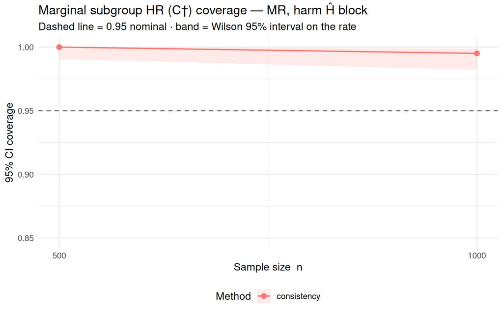

```r
target_pick    <- "C_dagger"   # "C_dagger" (θ†, marginal HR) | "C_ddagger" (θ‡, CDE) | "C_oracle"
estimator_pick <- "MR"         # "MR" | "naive" | "oracle"
block_pick     <- "H"          # "H" | "Hc"
band           <- "wilson"     # "wilson" | "mc_se" | "none"

if (have_grid) {
  pretty_tgt <- c(C_dagger = "Marginal subgroup HR (C\u2020)",
                  C_ddagger = "CDE (C\u2021)",
                  C_oracle = "Per-replicate oracle",
                  C_betaHhat = "Conditional HR \u03b2(\u0124)")[[target_pick]]
  sl <- subset(grid$coverage, target == target_pick &
                              estimator == estimator_pick & block == block_pick)
  sl <- sl[order(sl$n_sample), ]

  if (nrow(sl)) {
    p <- ggplot(sl, aes(n_sample, coverage, colour = subgroup_method,
                        fill = subgroup_method, group = subgroup_method))
    if (band == "wilson")
      p <- p + geom_ribbon(aes(ymin = wilson_lo, ymax = wilson_hi), alpha = 0.15, colour = NA)
    if (band == "mc_se")
      p <- p + geom_ribbon(aes(ymin = coverage - mc_se, ymax = coverage + mc_se),
                           alpha = 0.15, colour = NA)
    y_lo <- min(0.85, min(sl$wilson_lo, sl$coverage, na.rm = TRUE))
    print(
      p + geom_hline(yintercept = 0.95, linetype = 2, colour = "grey40") +
        geom_line(linewidth = 0.7) + geom_point(size = 2.4) +
        scale_x_continuous(breaks = sort(unique(sl$n_sample))) +
        coord_cartesian(ylim = c(y_lo, 1.0)) +
        labs(x = "Sample size  n", y = "95% CI coverage",
             colour = "Method", fill = "Method",
             title = sprintf("%s coverage — %s, %s block", pretty_tgt, estimator_pick,
                             if (block_pick == "H") "harm \u0124" else "complement \u0124\u1d9c"),
             subtitle = "Dashed line = 0.95 nominal · band = Wilson 95% interval on the rate") +
        theme_minimal(base_size = 12) + theme(legend.position = "bottom"))
  } else {
    cat("No rows for the chosen slice yet.\n")
  }
}
```

```r
if (have_grid && exists("sl") && nrow(sl)) {
  disp <- sl[, c("subgroup_method", "n_sample", "coverage", "mc_se",
                 "wilson_lo", "wilson_hi", "n_eff", "n_detected", "det_rate")]
  for (cc in c("coverage", "mc_se", "wilson_lo", "wilson_hi", "det_rate"))
    disp[[cc]] <- round(disp[[cc]], 3)
  knitr::kable(disp, row.names = FALSE,
               caption = sprintf("%s · %s estimator · %s block.",
                                 target_pick, estimator_pick, block_pick))
}
```

C_dagger · MR estimator · H block.

| subgroup_method | n_sample | coverage | mc_se | wilson_lo | wilson_hi | n_eff | n_detected | det_rate |
| --- | --- | --- | --- | --- | --- | --- | --- | --- |
| consistency | 500 | 1.000 | 0.000 | 0.991 | 1.000 | 404 | 404 | 0.808 |
| consistency | 1000 | 0.995 | 0.003 | 0.982 | 0.999 | 405 | 405 | 0.810 |

## 9.1 95% CI length vs sample size

Median width of the 95% CI for the chosen estimator/block as a function of *n* (median is robust to the occasional IJ blow-up; the band is the interquartile range across replicates). Same `estimator_pick` / `block_pick` as above; length is target-independent, so it has no C†/C‡ axis.

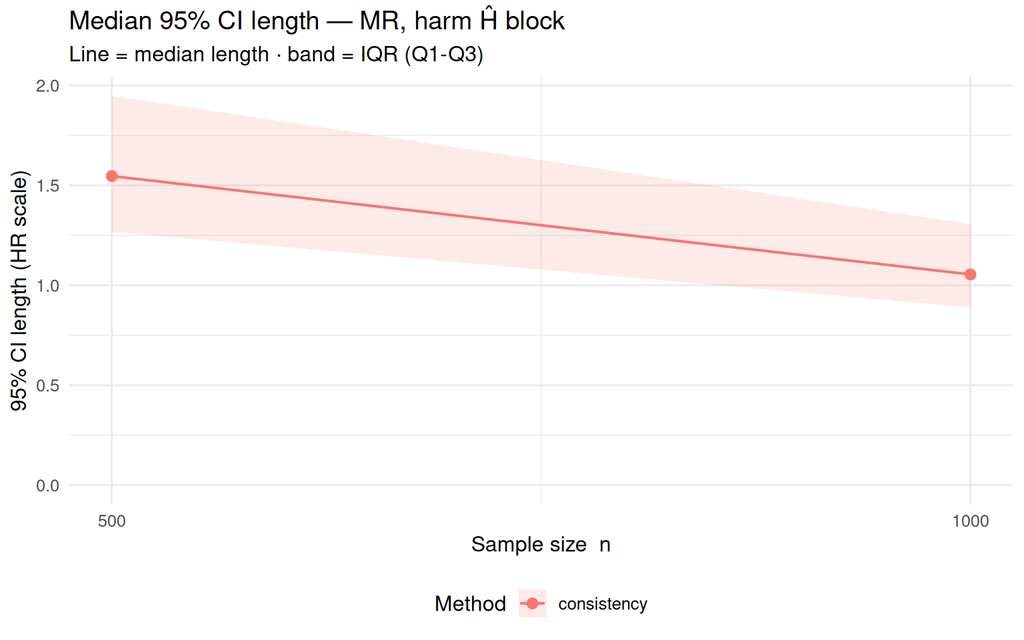

```r
if (have_grid && !is.null(grid$length)) {
  sl_len <- subset(grid$length, estimator == estimator_pick & block == block_pick)
  sl_len <- sl_len[order(sl_len$subgroup_method, sl_len$n_sample), ]
  if (nrow(sl_len)) {
    print(
      ggplot(sl_len, aes(n_sample, len_med, colour = subgroup_method,
                         fill = subgroup_method, group = subgroup_method)) +
        geom_ribbon(aes(ymin = len_q25, ymax = len_q75), alpha = 0.15, colour = NA) +
        geom_line(linewidth = 0.7) + geom_point(size = 2.4) +
        scale_x_continuous(breaks = sort(unique(sl_len$n_sample))) +
        expand_limits(y = 0) +
        labs(x = "Sample size  n", y = "95% CI length (HR scale)",
             colour = "Method", fill = "Method",
             title = sprintf("Median 95%% CI length — %s, %s block", estimator_pick,
                             if (block_pick == "H") "harm \u0124" else "complement \u0124\u1d9c"),
             subtitle = "Line = median length · band = IQR (Q1-Q3)") +
        theme_minimal(base_size = 12) + theme(legend.position = "bottom"))
  } else cat("No rows for the chosen length slice yet.\n")
}
```

## 9.2 Detection rate (companion)

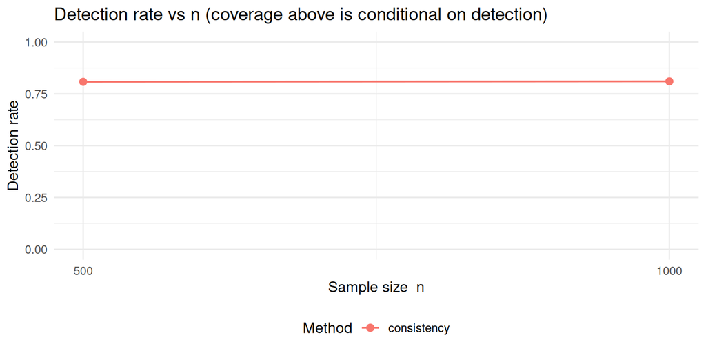

```r
if (have_grid) {
  print(
    ggplot(grid$manifest, aes(n_sample, det_rate, colour = subgroup_method,
                              group = subgroup_method)) +
      geom_line(linewidth = 0.7) + geom_point(size = 2.4) +
      scale_x_continuous(breaks = sort(unique(grid$manifest$n_sample))) +
      coord_cartesian(ylim = c(0, 1)) +
      labs(x = "Sample size  n", y = "Detection rate", colour = "Method",
           title = "Detection rate vs n (coverage above is conditional on detection)") +
      theme_minimal(base_size = 12) + theme(legend.position = "bottom"))
}
```

```r
if (have_grid) {
  cat(sprintf("Grid built %s from %d cell(s).\n", format(grid$built), nrow(grid$manifest)))
  knitr::kable(grid$manifest, row.names = FALSE, caption = "Cells ingested.")
}
```

```
Grid built 2026-08-19 12:25:12 from 2 cell(s).
```

Cells ingested.

| file | subgroup_method | n_sample | n_sims | n_detected | det_rate | mr_draws | nb_boots | seed_base |
| --- | --- | --- | --- | --- | --- | --- | --- | --- |
| fs_mr_n500_res.rds | consistency | 500 | 500 | 404 | 0.808 | 5000 | NA | 8316951 |
| fs_mr_n1000_res.rds | consistency | 1000 | 500 | 405 | 0.810 | 5000 | NA | 8316951 |

```r
if (!is.null(sweep_log)) {
  cat("\nThis render's sweep activity:\n")
  knitr::kable(sweep_log, row.names = FALSE, caption = "Per-cell run status this render.")
}
```

```
This render's sweep activity:
```

Per-cell run status this render.

| subgroup_method | n_sample | status | elapsed_sec | n_detected | file |
| --- | --- | --- | --- | --- | --- |
| consistency | 500 | skip | NA | NA | fs_mr_n500_res.rds |
| consistency | 1000 | skip | NA | NA | fs_mr_n1000_res.rds |

# 10 Session info

```r
.fmt_dur <- function(s) {
  h <- s %/% 3600; m <- (s %% 3600) %/% 60; sec <- round(s %% 60)
  if (h >= 1) sprintf("%d h %02d m %02d s", h, m, sec)
  else if (m >= 1) sprintf("%d m %02d s", m, sec) else sprintf("%.1f s", s)
}
cat(sprintf("TOTAL wall-clock, start to finish: %s\n",
            .fmt_dur(as.numeric(difftime(Sys.time(), .t0_doc, units = "secs")))))
```

```
TOTAL wall-clock, start to finish: 7.1 s
```